# Lydia_ModelFinal

## Prediction Accuracy

```r
modelAnalysis(model3, test_data)
```

|  | model_values |
| --- | --- |
| Training R^2 | 0.7322955 |
| Test R^2 | 0.6774364 |
| RMSE | 139.3056785 |

This model performs better on the training data, with a slightly lower adjusted $R^2$ on the testing data. The RMSE, however, is still relatively low, showing that it is not completely useless in predicting expenditure. A test adjusted $R^2$ of .6774 and a RMSE of 139.306 shows that this model generalizes moderately well, with only slight instability between training and testing.

## Model Reflection and Interpretation

My final model is as follows:

$E[expenditure] = -204.6722 + 1491.9818(\sqrt{share}) + -10.0464(dependents) + 2.9297(active) + 146.9072(\sqrt{share})(dependents)$

The intercept is not useful, as a negative value for expenditure is not possible. Across all $B_1 \rightarrow B_4$, it is easy to see that $\sqrt{share}$ is the most important predictor variable. $B_1$ is much higher than all other predictors. The next highest is $B_4$, which is the interaction between $\sqrt{share}$ and dependents. Active was found to also have a small significant effect. Dependents on its own was not significant.

The most important change to our model was dropping income since it added redundant information and made the least squares method “break”. Removing income made our residuals closer to normality and made our model and beta coefficients easier to interpret. When trying out different combinations of transformations, higher-order terms, and predictor variables, I obtained models that were slightly closer to passing residual analysis. None passed, however. Because none of my models passed residual analysis, I decided to used a much simpler model that was much more interpretable and still reasonably close to passing our residual analysis. Using the complex models would’ve left me with a model that did not satisfy the residual assumptions and would be useless practically, since the data was so transformed.

# Shreya’s individual work

### Data Import

```
##   card reports      age income       share expenditure owner selfemp dependents
## 1  yes       0 37.66667 4.5200 0.033269910  124.983300   yes      no          3
## 2  yes       0 33.25000 2.4200 0.005216942    9.854167    no      no          3
## 3  yes       0 33.66667 4.5000 0.004155556   15.000000   yes      no          4
## 4  yes       0 30.50000 2.5400 0.065213780  137.869200    no      no          0
## 5  yes       0 32.16667 9.7867 0.067050590  546.503300   yes      no          2
## 6  yes       0 23.25000 2.5000 0.044438400   91.996670    no      no          0
##   months majorcards active
## 1     54          1     12
## 2     34          1     13
## 3     58          1      5
## 4     25          1      7
## 5     64          1      5
## 6     54          1      1
```

### Week 8 Model:

```r
week8 <- lm(expenditure ~ income + sqrt(share) + dependents + months + active + share:dependents, data = train_data)
summary(week8)
```

```
##
## Call:
## lm(formula = expenditure ~ income + sqrt(share) + dependents +
##     months + active + share:dependents, data = train_data)
##
## Residuals:
##     Min      1Q  Median      3Q     Max
## -387.87  -67.49  -30.17   54.72 1961.29
##
## Coefficients:
##                    Estimate Std. Error t value     Pr(>|t|)
## (Intercept)      -217.00428   13.32532 -16.285      < 2e-16 ***
## income             49.54140    2.85155  17.373      < 2e-16 ***
## sqrt(share)      1188.98693   33.64067  35.344      < 2e-16 ***
## dependents        -26.43914    4.63038  -5.710 0.0000000153 ***
## months             -0.16954    0.06639  -2.554       0.0108 *
## active             -0.57078    0.72363  -0.789       0.4304
## dependents:share  491.17114   43.38666  11.321      < 2e-16 ***
## ---
## Signif. codes:  0 '***' 0.001 '**' 0.01 '*' 0.05 '.' 0.1 ' ' 1
##
## Residual standard error: 137.1 on 916 degrees of freedom
## Multiple R-squared:  0.7572, Adjusted R-squared:  0.7556
## F-statistic: 476.1 on 6 and 916 DF,  p-value: < 2.2e-16
```

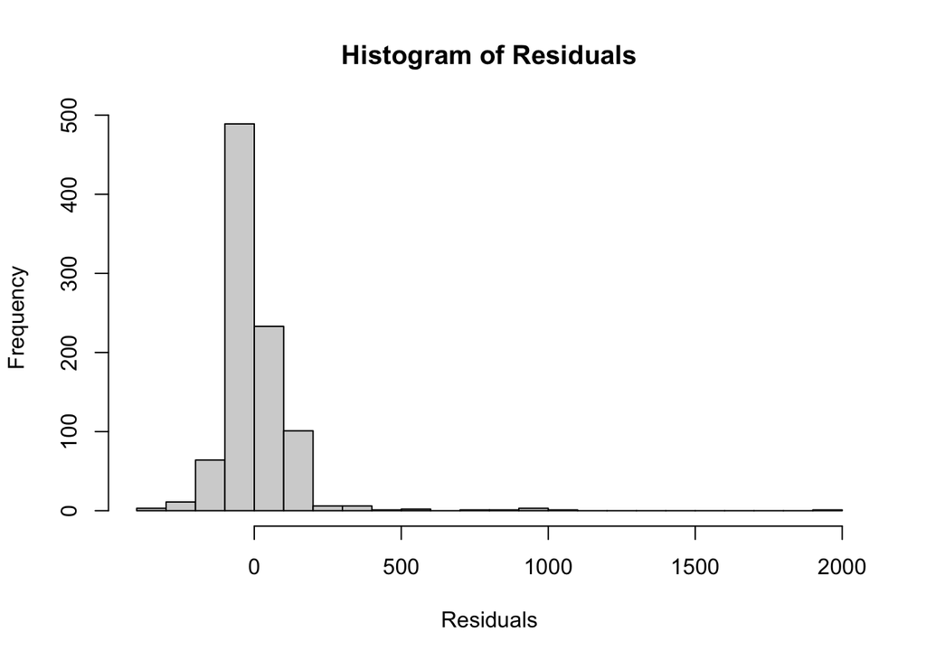

```r
res <- residuals(week8)
hist(res,
     main = "Histogram of Residuals",
     xlab = "Residuals",
     breaks = 30)
```

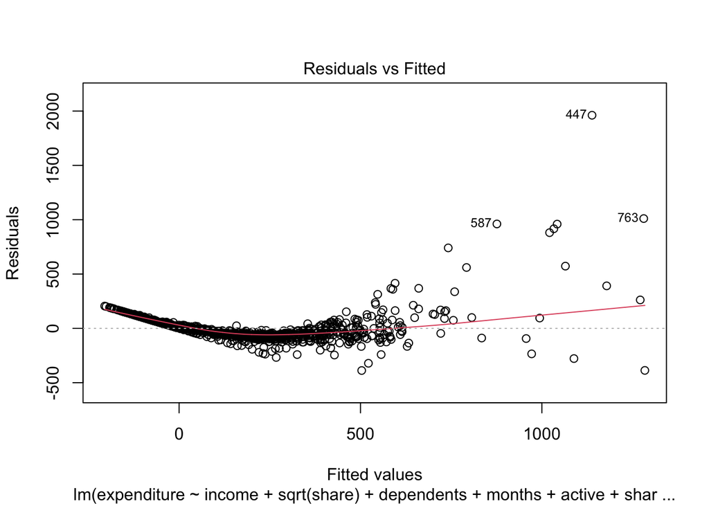

```r
plot(week8, which = 1)
```

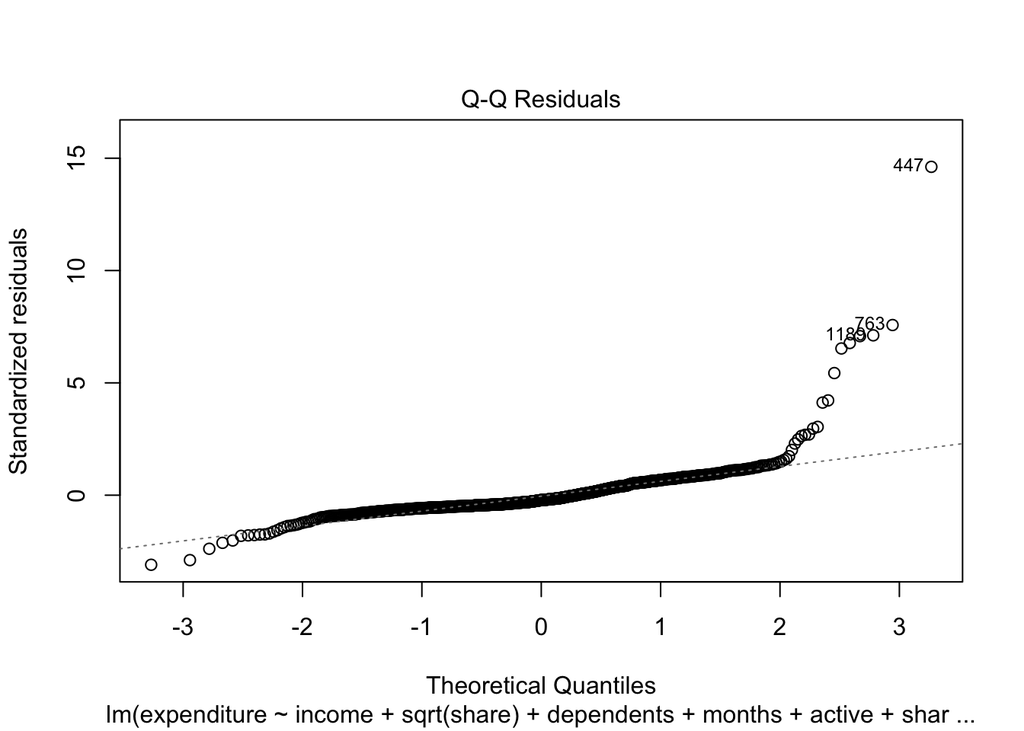

```r
plot(week8, which = 2)
```

```r
dwtest(week8)
```

```
##
##  Durbin-Watson test
##
## data:  week8
## DW = 2.0152, p-value = 0.5907
## alternative hypothesis: true autocorrelation is greater than 0
```

The model I had last week did not satisfy the assumption for residuals or normality. Although a lot of the predictors were significant we wanted to run an anova comparison to see if we could simplify our model while still making accurate predictions.

### Data Cleaning

```r
credit_data <- read.csv("credit_card_data.csv")
set.seed(862336550)
credit_data <- subset(credit_data, dependents != 0)
credit_data <- subset(credit_data, expenditure != 0)

n <- nrow(credit_data)

train_index <- sample(1:n, size = 0.7 * n)

train_data <- credit_data[train_index, ]

test_data  <- credit_data[-train_index, ]
nrow(credit_data)
```

```
## [1] 496
```

```r
nrow(train_data)
```

```
## [1] 347
```

```r
nrow(test_data)
```

```
## [1] 149
```

Data cleaning was necessary as our data according to the data logs, dependents equals 1 + number of dependents. However, there is an error in the dataset in this case as we have observations where dependents = 0. Thus, we removed these observations for consistency. We also removed the observations where expenditure = 0 as these are meaningless for our predictions.

### Step 1 — Simplify Your Expanded Model (Individual Work)

#### Using the model you ended with last week (or your latest model) — which may include:

Here I removed income from last weeks model. This is because income and share provide reciprocal information. The partial F test said we should keeo income, but this is because the reciprocal relationship is causing it to provide invalid results. We decided to keep share as it seemed more representative when predicting expenditure as it is the ratio of monthly credit card expenditure to yearly income.

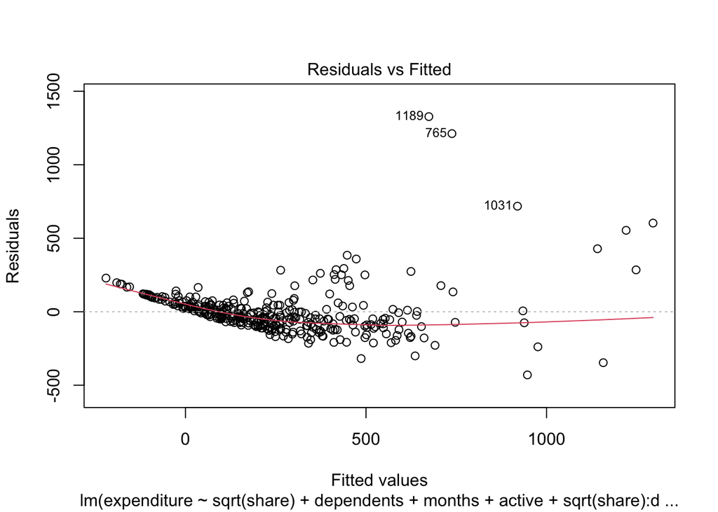

```r
model1 <- lm(expenditure ~ sqrt(share) + dependents + months + active + sqrt(share):dependents, data = train_data)
plot(model1, which = 1)
```

```r
dwtest(model1)
```

```
##
##  Durbin-Watson test
##
## data:  model1
## DW = 1.983, p-value = 0.436
## alternative hypothesis: true autocorrelation is greater than 0
```

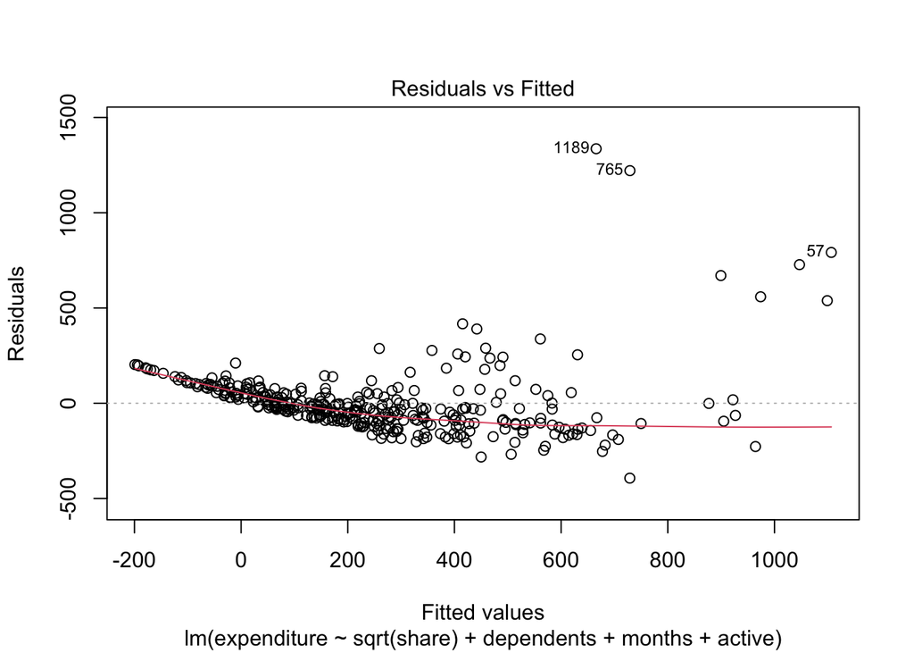

```r
model2 <- lm(expenditure ~ sqrt(share) + dependents + months + active, data = train_data)
plot(model2, which = 1)
```

```r
dwtest(model2)
```

```
##
##  Durbin-Watson test
##
## data:  model2
## DW = 2.0012, p-value = 0.5045
## alternative hypothesis: true autocorrelation is greater than 0
```

```r
anova(model1, model2)
```

```
## Analysis of Variance Table
##
## Model 1: expenditure ~ sqrt(share) + dependents + months + active + sqrt(share):dependents
## Model 2: expenditure ~ sqrt(share) + dependents + months + active
##   Res.Df     RSS Df Sum of Sq      F          Pr(>F)
## 1    341 8833608
## 2    342 9881366 -1  -1047758 40.446 0.0000000006497 ***
## ---
## Signif. codes:  0 '***' 0.001 '**' 0.01 '*' 0.05 '.' 0.1 ' ' 1
```

The partial F test shows a very small p value for the comparison between the full model (with interaction) and the reduced model (without interaction). This means that the interaction share:dependents is highly significant and that we should proceed with the full model.

```r
model2 <- lm(expenditure ~ sqrt(share) + dependents + months + active + sqrt(share):dependents, data = train_data)

model3 <- lm(expenditure ~ sqrt(share) + dependents + active + sqrt(share):dependents, data = train_data)
dwtest(model3)
```

```
##
##  Durbin-Watson test
##
## data:  model3
## DW = 1.9849, p-value = 0.4421
## alternative hypothesis: true autocorrelation is greater than 0
```

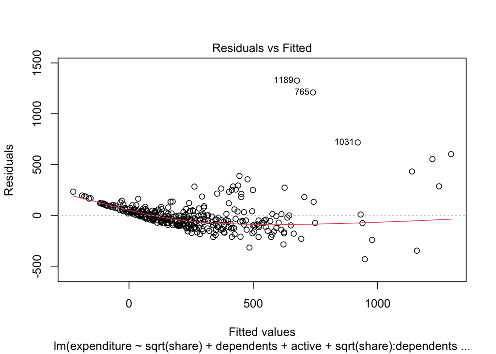

```r
plot(model3, which = 1)
```

```r
summary(model3)
```

```
##
## Call:
## lm(formula = expenditure ~ sqrt(share) + dependents + active +
##     sqrt(share):dependents, data = train_data)
##
## Residuals:
##     Min      1Q  Median      3Q     Max
## -431.25  -77.59  -22.27   43.91 1325.99
##
## Coefficients:
##                        Estimate Std. Error t value Pr(>|t|)
## (Intercept)            -131.006     42.364  -3.092  0.00215 **
## sqrt(share)            1088.574    140.219   7.763 9.68e-14 ***
## dependents              -50.883     17.852  -2.850  0.00463 **
## active                    1.314      1.387   0.947  0.34418
## sqrt(share):dependents  400.770     62.984   6.363 6.35e-10 ***
## ---
## Signif. codes:  0 '***' 0.001 '**' 0.01 '*' 0.05 '.' 0.1 ' ' 1
##
## Residual standard error: 160.7 on 342 degrees of freedom
## Multiple R-squared:  0.705,  Adjusted R-squared:  0.7016
## F-statistic: 204.3 on 4 and 342 DF,  p-value: < 2.2e-16
```

```r
anova(model2, model3)
```

```
## Analysis of Variance Table
##
## Model 1: expenditure ~ sqrt(share) + dependents + months + active + sqrt(share):dependents
## Model 2: expenditure ~ sqrt(share) + dependents + active + sqrt(share):dependents
##   Res.Df     RSS Df Sum of Sq      F Pr(>F)
## 1    341 8833608
## 2    342 8836836 -1   -3227.3 0.1246 0.7243
```

The partial F-test comparing the full model (including months) to the reduced model (excluding months) yields a large p-value, indicating that months is not a significant predictor. Therefore, we can proceed with the reduced model without months.

```r
model3 <- lm(expenditure ~ sqrt(share) + dependents + active + sqrt(share):dependents, data = train_data)

model4 <- lm(expenditure ~ sqrt(share) + dependents + sqrt(share):dependents, data = train_data)
dwtest(model4)
```

```
##
##  Durbin-Watson test
##
## data:  model4
## DW = 1.9933, p-value = 0.4713
## alternative hypothesis: true autocorrelation is greater than 0
```

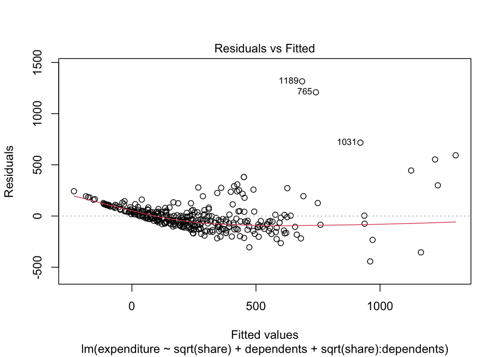

```r
plot(model4, which = 1)
```

```r
summary(model4)
```

```
##
## Call:
## lm(formula = expenditure ~ sqrt(share) + dependents + sqrt(share):dependents,
##     data = train_data)
##
## Residuals:
##     Min      1Q  Median      3Q     Max
## -443.01  -82.52  -17.71   43.48 1315.50
##
## Coefficients:
##                        Estimate Std. Error t value Pr(>|t|)
## (Intercept)             -120.44      40.86  -2.947  0.00342 **
## sqrt(share)             1087.27     140.19   7.756 1.01e-13 ***
## dependents               -50.53      17.85  -2.832  0.00490 **
## sqrt(share):dependents   400.61      62.97   6.361 6.39e-10 ***
## ---
## Signif. codes:  0 '***' 0.001 '**' 0.01 '*' 0.05 '.' 0.1 ' ' 1
##
## Residual standard error: 160.7 on 343 degrees of freedom
## Multiple R-squared:  0.7042, Adjusted R-squared:  0.7017
## F-statistic: 272.2 on 3 and 343 DF,  p-value: < 2.2e-16
```

```r
anova(model3, model4)
```

```
## Analysis of Variance Table
##
## Model 1: expenditure ~ sqrt(share) + dependents + active + sqrt(share):dependents
## Model 2: expenditure ~ sqrt(share) + dependents + sqrt(share):dependents
##   Res.Df     RSS Df Sum of Sq      F Pr(>F)
## 1    342 8836836
## 2    343 8860020 -1    -23185 0.8973 0.3442
```

The partial F-test comparing the full model (including active) to the reduced model (excluding active) yields a large p-value, indicating that active is not a significant predictor. Therefore, we can proceed with the reduced model without active

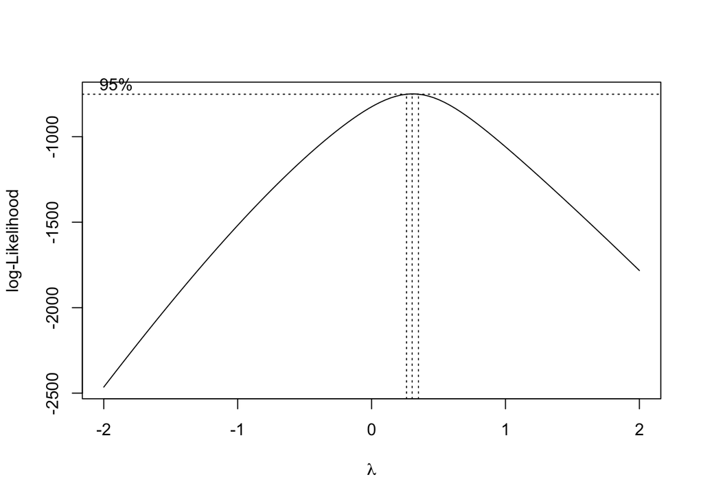

```r
# Box-Cox transformation
boxcox(model4, lambda = seq(-2, 2, 0.1))
```

```r
train_data <- train_data[-c(1189, 765, 295), ]
final_model <- lm(sqrt(expenditure) ~ sqrt(share) + dependents + sqrt(share):dependents, data = train_data)
summary(final_model)
```

```
##
## Call:
## lm(formula = sqrt(expenditure) ~ sqrt(share) + dependents + sqrt(share):dependents,
##     data = train_data)
##
## Residuals:
##     Min      1Q  Median      3Q     Max
## -8.3794 -1.8060 -0.4387  1.3529 18.3524
##
## Coefficients:
##                        Estimate Std. Error t value     Pr(>|t|)
## (Intercept)              1.3297     0.7730   1.720       0.0863 .
## sqrt(share)             40.6148     2.6542  15.302      < 2e-16 ***
## dependents              -0.5161     0.3371  -1.531       0.1267
## sqrt(share):dependents   6.8362     1.1896   5.746 0.0000000202 ***
## ---
## Signif. codes:  0 '***' 0.001 '**' 0.01 '*' 0.05 '.' 0.1 ' ' 1
##
## Residual standard error: 3.036 on 342 degrees of freedom
## Multiple R-squared:  0.8391, Adjusted R-squared:  0.8377
## F-statistic: 594.7 on 3 and 342 DF,  p-value: < 2.2e-16
```

### Step 2 — Residual & Assumption Review

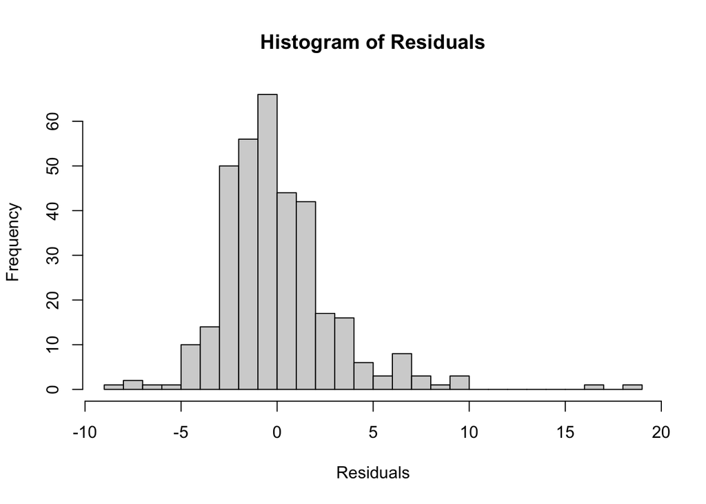

```r
res <- residuals(final_model)
hist(res,
     main = "Histogram of Residuals",
     xlab = "Residuals",
     breaks = 30)
```

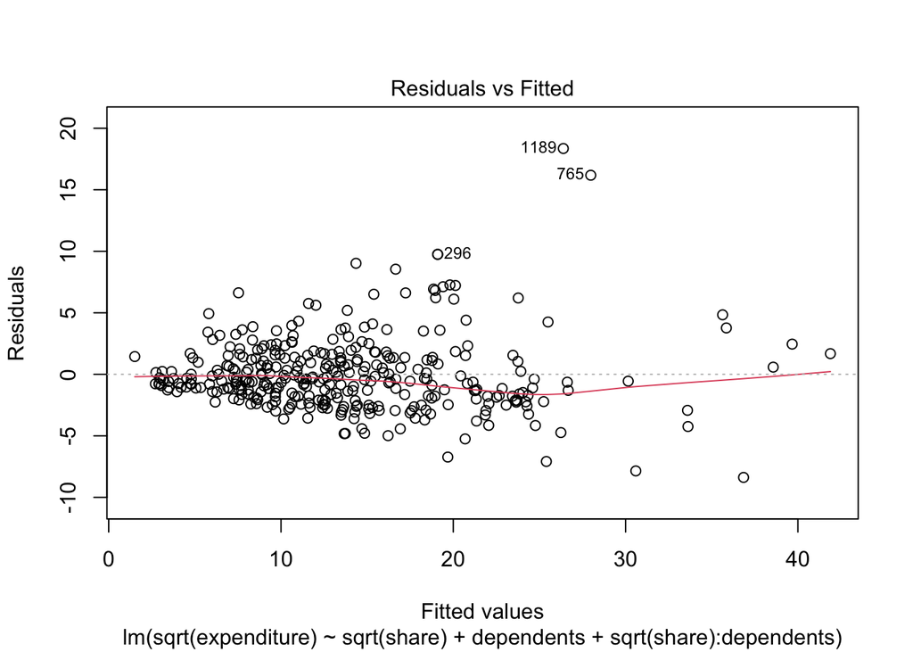

```r
plot(final_model, which = 1)
```

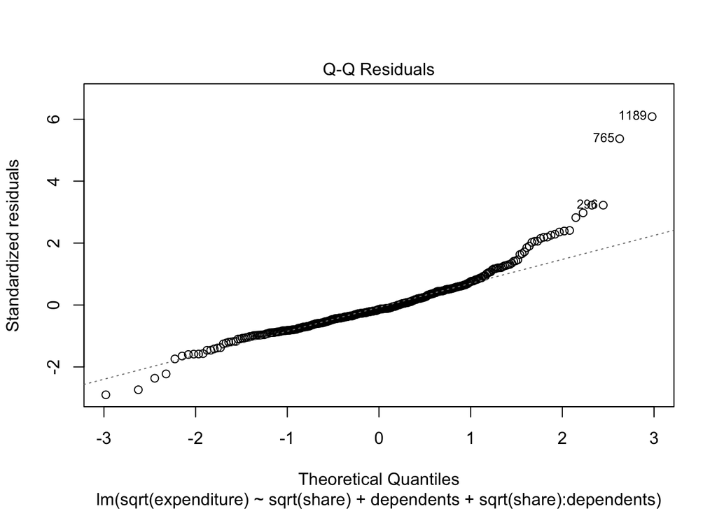

```r
plot(final_model, which = 2)
```

```r
dwtest(final_model)
```

```
##
##  Durbin-Watson test
##
## data:  final_model
## DW = 1.96, p-value = 0.3518
## alternative hypothesis: true autocorrelation is greater than 0
```

Applying the square root transformation improved the residual vs. fitted plot and the Q-Q plot, reducing the appearance of heteroskedasticity and making the model diagnostics more reasonable, even if not perfect.

This improvement is consistent with our EDA, which showed that the relationships between expenditure and the predictor variables exhibit heteroskedasticity. Given the variability in the data, it is unrealistic to expect a model with perfectly homoskedastic residuals while still maintaining interpretability.